# Python

```python
print('Hello world')
```

```
Hello world
```

Подпрограмма, выполняющая определенные действия, называется **функцией**.

### Функция print()

> выводит на экран переданные в неё данные - **аргументы**, или **параметры**. Они перечисляются после имени функции в скобках.

Необязательные аргументы:

- **end=''** - добавляется после последнего значения (по умолчанию **'\n'** - перенос на новую строку).
- **sep=''** - разделитель объектов (по умолчанию - пробел).

```python
print('Hello world')

# вызов функции print() с аргументом 'Hello world'
```

```
Hello world
```

Строка, начинающаяся с символа # — это **комментарий**. Python игнорирует любые символы в строке после #, не считает их кодом.

```python
print(1, 2, 3)
print(1, 2, 3, sep=', ')
print(1, 2, 3, sep='; ', end=' -end-\n')
print(1, 2, 3, end=' -end- ')
```

```
1 2 3
1, 2, 3
1; 2; 3 -end-
1 2 3 -end-
```

## Переменные и типы

> имя переменной может состоять из букв латинского алфавита, цифр и подчеркивания;

> если название состоит из нескольких слов, разделяйте их символом нижнего подчёркивания;

> Python допускает использование цифр в именах переменных, но не на первой позиции;

> все строки – Unicode;

> составляйте названия переменных из английских слов;

> двойные и одинарные кавычки равнозначны;

> переменная в процессе работы программы может менять свои значения и тип;

> в Python имена переменных начинаются с маленькой буквы.

```python
steps_today = 10234
# создали «коробку» с именем steps и положили в неё значение 10234
print(steps_today)
```

```
10234
```

```python
message = 'Hello world'
# объявили переменную message и присвоили ей значение: строку 'Hello world'
print(message)
```

```
Hello world
```

```python
# старое значение уже "забыто"
message = 8
print(message)
```

```
8
```

Переменные в Python могут быть разного типа.

### Некоторые типы данных в Python

| Имя | Тип | Пример |
| --- | --- | --- |
| Целые числа | int | 42 |
| Числа с плавающей точкой | float | 3.14 |
| Строки | str | 'hello', '42' |
| Булевый тип | bool | True/False |
| NoneType | NoneType | None |

```python
type(42)
```

```
int
```

```python
type(3.14)
```

```
float
```

```python
type('hello')
```

```
str
```

```python
type(5 < 6)
```

```
bool
```

### Числа

```python
year = 2020
print(year)
```

```
2020
```

```python
pi = 3.14
pi
```

```
3.14
```

| Операция | Результат |
| --- | --- |
| num + num2 | Сложение |
| num - num2 | Вычитание |
| num == num2 | Равенство |
| num != num2 | Неравенство |
| num >= num2 | Больше или равно |
| num > num2 | Больше |
| num * num2 | Умножение |
| num / num2 | Деление |
| num // num2 | Целочисленное деление |
| num % num2 | Остаток от деления |
| num ** num2 | Возведение в степень |

```python
print(7 / 2)
print(7 // 2)
print(7 % 2)
```

```
3.5
3
1
```

```python
2**10
```

```
1024
```

### Строки

```python
fav_subject = 'Mathematics'
print(fav_subject)
```

```
Mathematics
```

| Операция | Результат |
| --- | --- |
| s + s2 | Сложение |
| 'math' in s2 | Вхождение |
| s == s2 | Равенство |
| s != s2 | Неравенство |
| s >= s2 | Больше или равно |
| s > s2 | Больше |
| s * num | Повторение |
| s[0] | Доступ по индексу |
| len(s) | Длина строки |

```python
'one' + 'two'
```

```
'onetwo'
```

```python
'3' + '3'
```

```
'33'
```

```python
# оператор in определяет вхождение левого аргумента в правый

'math' in 'mathematics'
```

```
True
```

```python
# функция ord() принимает строковый аргумент из одного символа Юникода и возвращает его целочисленное значение

help(ord)
```

```
Help on built-in function ord in module builtins:

ord(c, /)
    Return the Unicode code point for a one-character string.
```

```python
'a' > 'b'

# ord('a') # 97

# ord('b') # 98
```

```
False
```

```python
'*' * 10
```

```
'**********'
```

```python
print('python'[1])
```

```
y
```

```python
len('python')
```

```
6
```

> Метод **.split()** разбивает строку на части, используя разделитель, и возвращает эти части в виде списка.

```python
course_list = 'mathematics, physics, biology'
print(course_list)
print(type(course_list))
print()
splitted = course_list.split(', ') # разделитель: по запятой и пробелу

print(splitted)
print(type(splitted))
```

```
mathematics, physics, biology
<class 'str'>

['mathematics', 'physics', 'biology']
<class 'list'>
```

> Метод **.join()** собирает строку из списка, используя разделитель.

```python
# список строк можно преобразовать в одну строку
print(splitted)
print(type(splitted))
print()

print(' '.join(splitted))
print(type(' '.join(splitted)))
```

```
['mathematics', 'physics', 'biology']
<class 'list'>

mathematics physics biology
<class 'str'>
```

> Метод **.strip()** возвращает копию указанной строки, с обоих концов которой удалены указанные символы.  
> Символы удаляются с начала строки и до достижения символа, который не содержится в наборе символов аргумента. Аналогичное действие происходит и в конце строки.

```python
text = ' 1234    '
text = text.strip() # отрезает пробелы(по умолчанию) с обеих сторон
text
```

```
'1234'
```

```python
input_string = ' 79151004557'
input_string = input_string.strip(' 970')
input_string
```

```
'15100455'
```

### Преобразование типов

```python
print(100 + ' рублей')
```

```
---------------------------------------------------------------------------
TypeError                                 Traceback (most recent call last)
<ipython-input-13-f429f6124170> in <module>
----> 1 print(100 + ' рублей')

TypeError: unsupported operand type(s) for +: 'int' and 'str'
```

> Функция **str()** - преобразование в строку.

```python
print(str(100) + ' рублей')
```

```
100 рублей
```

> Функция **int()** - преобразование в целое число.

```python
a = int('3')
print(a, type(a))
```

```
3 <class 'int'>
```

```python
int('три')
```

```
---------------------------------------------------------------------------
ValueError                                Traceback (most recent call last)
<ipython-input-100-470d24bc77b7> in <module>
----> 1 int('три')

ValueError: invalid literal for int() with base 10: 'три'
```

> Функция **float()** - преобразование в число с плавающей точкой.

```python
type(float('3.14'))
```

```
float
```

### Булевый тип

| **True** | **False** |
| --- | --- |
| True | False |
| Большинство объектов | None |
| 1 | 0 |
| 4.2 | 0.0 |
| 'string' | '' |

```python
10 > 9
```

```
True
```

```python
a = 10
b = 10

print(a <= b)
```

```
True
```

```python
1 < a < 5
```

```
False
```

```python
b3 = (12 % 2) == 0
b3
```

```
True
```

```python
bool('')
```

```
False
```

```python
bool(0)
```

```
False
```

## Логические операторы

> Оператор **or**, «логическое ИЛИ», возвращает True, **если хотя бы одно из условий истинно.**  
> Если первый аргумент оператора or возвращает True, то второй аргумент не оценивается, так как ответ уже ясен.

```python
1 or 0
```

```
1
```

> Оператор **and**, «логическое И», возвращает True только **если оба условия истинны.**  
> Если один из аргументов оператора and возвращает False, то другой аргумент уже не оценивается: оператор в любом случае вернёт False.

```python
1 and 0
```

```
0
```

> Оператор **not** — это логическое отрицание.

```python
not True
```

```
False
```

```python
wind = True

# Есть ли ветер?
if not wind: # Если wind НЕ равен True
    print('Ночь тиха')
else:
    print('Ветрено')
```

```
Ветрено
```

## Ветвления

Если выражение в условии истинно, то выполняется блок инструкций после двоеточия. Если ложно, код после условия не сработает.

```python
if 5:
    print('**')
if 0:
    print('xx')
if -1:
    print('--')
```

[output not shown]

Как только выполняется одно из условий, все следующие elif игнорируются вместе с else.

```python
number = 10
if number % 2 == 0:
    print('Кратно 2')
elif number % 5 == 0:
    print('Кратно 5') # второе условие не проверялось, потому что выполнилось первое
```

```
Кратно 2
```

```python
number = 10
if number % 2 == 0:
    print('Кратно 2')
if number % 5 == 0:
    print('Кратно 5') # проверялись оба условия
```

```
Кратно 2
Кратно 5
```

```python
answer = input('What is the capital of Russia? ')
answer = answer.strip()

if answer == 'Moscow':
    print('Точно!')
elif (answer == 'moscow') or (answer == 'Москва') or (answer == 'москва'):
    print('Тоже вариант!')
else:
    print('Нет')
```

```
What is the capital of Russia? Moscow
Точно!
```

### Задача 1

Даны длины сторон треугольника. Проверить, является ли он прямоугольным.

```python
a = 1
b = 2
c = 3
if a + c <= b or b + c <= a or a + b <= c:
    print('Треугольник не существует')
else:
    if (a**2 + b**2 == c**2) or b**2 + c**2 == a**2 or a**2 + c**2 == b**2:
        print('Является прямоугольным')
    else:
        print('Не является прямоугольным')
```

```
Треугольник не существует
```

```python
a = 3
b = 4
c = 5
if a + b > c and b + c > a and c + a > b:
    if a**2 + b**2 == c**2 or b**2 + c**2 == a**2 or a**2 + c**2 == b**2:
        print('Является прямоугольным')
    else:
        print('Не является прямоугольным')
else:
    print('Треугольник не существует')
```

```
Является прямоугольным
```

## Циклы

```python
for letter in 'python':
    print(letter)
```

```
p
y
t
h
o
n
```

### Функция range()

> - функция, с помощью которой можно задать диапазон чисел.

Выражение range(a, b) возвращает числа от **a** до **b-1**. Если на месте a стоит ноль, range(0, N) вернёт ровно N значений.

```python
for i in range(5):
    print(i)
```

```
0
1
2
3
4
```

```python
for i in range(1, 1):
    print(i)
```

```python
patience = 5

while patience != 0:
    patience -= 1

    print(patience)
```

```
4
3
2
1
0
```

### Задача 2

Из заданного диапазона чисел вывести те, которые кратны 3 и 5.

```python
for number in range(1, 31):

    if number % 3 == 0 and number % 5 == 0:
        print(number, 'кратно 3 и 5')
```

```
15 кратно 3 и 5
30 кратно 3 и 5
```

## Пользовательский ввод

### Функция input()

> принимает введенные с клавиатуры данные.

Необязательные аргументы:

- **prompt=''** - сообщение, отображаемое перед вводом.

```python
input()
```

```
1
```

```
'1'
```

```python
input(prompt='you can type smth here: ')
```

```
you can type smth here: 2
```

```
'2'
```

```python
int(input())
```

```
2
```

```
2
```

## Модули

Библиотека или модуль — это набор готовых функций, объединённых общей темой. Например, в библиотеке math собраны функции для подсчёта математических величин.

```python
import math # теперь в программе можно пользоваться всеми функциями из модуля math
```

```python
help(math)
```

[output not shown]

[output cut: 209 more lines]

[output not shown]

```python
math.pi
```

```
3.141592653589793
```

```python
math.sqrt(9)
```

```
3.0
```

```python
# через Дискриминант
# x^2 + x -6 = 0
# x^2 -6x + 9 = 0
import math

a = int(input('Введите a: '))
b = int(input('Введите b: '))
c = int(input('Введите c: '))

D = b**2 - 4*a*c
print('Дискриминант =', D)

if D > 0:
    print('Два решения')
    x1 = (-b + math.sqrt(D))/(2*a)
    x2 = (-b - math.sqrt(D))/(2*a)
    print('x1 = {}; x2 = {}'.format(x1, x2))
elif D == 0:
    print('Одно решение')
    x1 = (-b)/(2*a)
    print('x1 =', x1)
else:
    print('Нет решений')
```

```
Введите a: 1
Введите b: 1
Введите c: -6
Дискриминант = 25
Два решения
x1 = 2.0; x2 = -3.0
```

```python
# через теорему Виета
a = int(input('Введите a: '))
b = int(input('Введите b: '))
c = int(input('Введите c: '))

D = b**2 - 4*a*c
if D > 0:
    flag = False
    for x1 in range(-10,11):
        for x2 in range(-10, 11):
            if x1 + x2 == -b / a and x1 * x2 == c / a:
                print('x1 = {}; x2 = {}'.format(x1, x2))
                flag = True
                break # оператор break прерывает цикл и выходит из него
        if flag:
            break
elif D == 0:
    for x1 in range(-10, 11):
        if x1 + x1 == -b / a and x1 * x1 == c / a:
                print('x1 = {}'.format(x1))
                break
else:
    print('Нет решений')
```

```
Введите a: 1
Введите b: 1
Введите c: -6
x1 = -3; x2 = 2
```

### Задача 3

Пользователем вводится число. Проверить, четное оно или нет.

```python
a = 10
if a % 2 == 0:
    print('Четное')
else:
    print('Нечетное')
```

```
Четное
```

### Задача 4

Найти сумму цифр числа.

```python
# пройтись по строке (способ №1)
total = 0
number = '1234'
for digit in number:
#     print(digit)
    total += int(digit)
print(total)
```

```
10
```

```python
# пройтись по строке (способ №2)
total = 0
number = '1234'
for i in range(0, len(number)):
#     print(number[i])
    total = total + int(number[i])
print(total)
```

```
10
```

```python
number = 1234
total = 0

while number > 0:
#     print(number % 10)
    total += number % 10
    number = number // 10
print(total)
```

```
10
```

### Задача 5

Вычислить факториал числа, введенного с клавиатуры.

```python
# способ №1
n = 3
factorial = 1
for i in range(1, n + 1):
    factorial = factorial * i
print(factorial)
```

```
6
```

```python
# способ №2
from math import factorial
factorial(3)
```

```
6
```

### ЗАДАНИЕ 2. Демонстрационный вариант ЕГЭ 2021.

Дан фрагмент таблицы истинности, состоящий из трех **различных** ее строк, функции $(x ∨ y) ∧ ¬(y ≡ z) ∧ ¬w$.

|  |  |  |  | (x ∨ y) ∧ ¬(y ≡ z) ∧ ¬w |
| --- | --- | --- | --- | --- |
| 1 |  | 1 |  | 1 |
| 0 | 1 |  | 0 | 1 |
|  | 1 | 1 | 0 | 1 |

Определите, какому столбцу таблицы соответствует каждая из переменных $w, x, y, z$. В ответ напишите буквы $w, x, y, z$ в том порядке, в котором идут соответствующие им столбцы (сначала буква, соответствующая первом столбцу; затем буква, соответствующая второму столбцу, и т.д.). Буквы в ответ пишите подряд, разделителей между буквами ставить не нужно.

```python
%%html
<style>
.table1 {border-collapse:collapse;border-spacing:0;}
.table1 td{border-color:black;border-style:solid;border-width:1px;font-size:14px;padding:10px 20px;}
.table1 th{border-color:black;border-style:solid;border-width:1px;font-size:14px;padding:10px 20px;}
.table1 .table1-cell{border-color:inherit;text-align:center;}
</style>
```

```python
print('x y z w')
for x in range(0,2):
    for y in range(0,2):
        for z in range(0,2):
            for w in range(0,2):
                if (x or y) and not(y == z) and (not w):
                    print(x, y, z, w)
```

```
x y z w
0 1 0 0
1 0 1 0
1 1 0 0
```

### ЗАДАНИЕ 2. Статград Тренировочная работа №1 от 22.10.2020.

Логическая функция F задается выражением: $(w ∨ ¬x) ∧ (w ≡ ¬y) ∧ (w → z)$.

Дан частично заполненный фрагмент, содержащий **неповторяющиеся** строки таблицы истинности функции F. Определите, какому столбцу таблицы истинности соответствует каждая из переменных $w, x, y, z$.

|  |  |  |  | (w ∨ ¬x) ∧ (w ≡ ¬y) ∧ (w → z) |
| --- | --- | --- | --- | --- |
| 1 |  | 1 | 1 | 1 |
|  |  | 1 |  | 1 |
| 1 |  | 1 |  | 1 |

В ответ напишите буквы $w, x, y, z$ в том порядке, в котором идут соответствующие им столбцы (сначала буква, соответствующая первом столбцу; затем буква, соответствующая второму столбцу, и т.д.). Буквы в ответ пишите подряд, разделителей между буквами ставить не нужно.

```python
%%html
<style>
.table2 {border-collapse:collapse;border-spacing:0;}
.table2 td{border-color:black;border-style:solid;border-width:1px;font-size:14px;padding:10px 20px;}
.table2 th{border-color:black;border-style:solid;border-width:1px;font-size:14px;padding:10px 20px;}
.table2 .table2-cell{border-color:inherit;text-align:center;}
</style>
```

```python
print('x y z w')
for x in range(0,2):
    for y in range(0,2):
        for z in range(0,2):
            for w in range(0,2):
                if (w or not x) and (w == (not y)) and (not w or z):
                    print(x, y, z, w)
```

```
x y z w
0 0 1 1
0 1 0 0
0 1 1 0
1 0 1 1
```

### Задача 6

Перевести число из 10-ой системы счисления в любую другую (до 16-тиричной включительно).

```python
# до 16-тиричной
num = 2748
from_base = 10
to_base = 16
s = ''

alphabet = '0123456789ABCDEF'
while num > to_base:
    s = alphabet[num % to_base] + s
    num = num // to_base
s = alphabet[num % to_base] + s
print(s)
```

```
ABC
```

### ЗАДАНИЕ 14. Статград Тренировочная работа №1 от 22.10.2020.

Значение выражения $81^{17} + 3^{24} - 45$ записали в системе счисления с основанием 9. Сколько цифр 8 содержится в этой записи?

```python
number = 81**17 + 3**24 - 45
base = 9 # Основание системы счисления
count_8 = 0

while number > 0:
    if number % base == 8:
        count_8 += 1
    number //= base
print('Количество цифр 8:', count_8)


# print(1 % 2) # 1
# print(1 // 2) # 0
```

```
Количество цифр 8: 10
```

### ЗАДАНИЕ 14. Статград Тренировочная работа №3 от 02.02.2021.

Значение выражения $343^{5} + 7^{3} - 1 - X$ записали в системе счисления с основанием 7, при этом в записи оказалось 12 цифр 6. При каком минимальном целом положительном X это возможно?

```python
for x in range(1, 1001):
    count_6 = 0
    number = 343**5 + 7**3 - 1 - x
    while number > 0:
        if number % 7 == 6:
            count_6 += 1
        number = number // 7
    if count_6 == 12:
        print('Минимальное целое положительное X:', x)
        break
```

```
Минимальное целое положительное X: 400
```

### Задача 7

```python
num = '1234'

# способ №1
print(num[0], num[len(num) - 1])

# способ №2
print(num[0], num[-1])
```

```
1 4
1 4
```

### Задача 8

Ввели пятизначное число. Определить является ли сумма первых двух чисел четным числом.

```python
# код
```

### Задача 9

Вывести все двузначные четные числа.

```python
# код
```

### Задача 10

Ввели имя. Напечатать: "Привет, {имя}"

```python
name = input('Введите имя: ')
print('Привет,', name)
```

```
Введите имя: Оля
Привет, Оля
```

### Задача 11

Вывести все буквы(каждая буква в новой строке) в слове, введенном с клавиатуры.

```python
a = input()
for letter in a:
    print(letter)
```

```
maths
m
a
t
h
s
```

## Функция

```python
def discriminant(a, b, c):
    d = b**2 - 4*a*c
    return d

discriminant(1, 1, -6)
```

```
25
```

```python
def f(x):
    """ Возведение числа в квадрат """
    y = x ** 2
    return y

print(f(3))
print(f(10))
```

```
9
100
```

```python
def add_numbers(x, y):
    return x + y

add_numbers(10, 5)
```

```
15
```

```python
def km_per_hour(x):
    """ Converts kilometers per hour to meters per second """
    return x * 1000 / 3600

print(km_per_hour(72))
print(km_per_hour(36))
```

```
20.0
10.0
```

### Задача 12

Проверить правильность введенного ответа.

```python
# без использования функции
print('В каком классе Андрей?')
correct_answer = 10
input_answer = int(input('Введите ответ: '))
if input_answer == correct_answer:
    print(input_answer, '- правильный ответ')
else:
    print(input_answer, '- неверный ответ')
```

```
В каком классе Андрей?
Введите ответ: 10
10 - правильный ответ
```

```python
# с использованием функции
def grade_check(input_answer=None):
    print('В каком классе Андрей?')
    CORRECT_ANSWER = 10
    if input_answer is None:
        input_answer = input('Введите ответ: ')
    if int(input_answer) == CORRECT_ANSWER:
        print(input_answer, '- правильный ответ')
    else:
        print(input_answer, '- неверный ответ')
    print()

grade_check()
grade_check()
# grade_check(9)
# grade_check(10)
```

```
В каком классе Андрей?
Введите ответ: 9
9 - неверный ответ

В каком классе Андрей?
Введите ответ: 10
10 - правильный ответ
```

### Задача 13

Нарисовать прямоугольник и его диагонали.

```python
def stars(n):
    SIGN = '*'
    for i in range(n):
        for j in range(n):
            if i == 0 or i == n-1 or j == 0 or j == n-1 or i == j or j == n-1-i:
                print(SIGN, end=' ')
            else:
                print(' ', end=' ')
        print()

stars(7)
```

[output not shown]

### Рекурсия

Рекурсивная функция - функция, которая вызывает саму себя.

### ЗАДАНИЕ 16. Демонстрационный вариант ЕГЭ 2021.

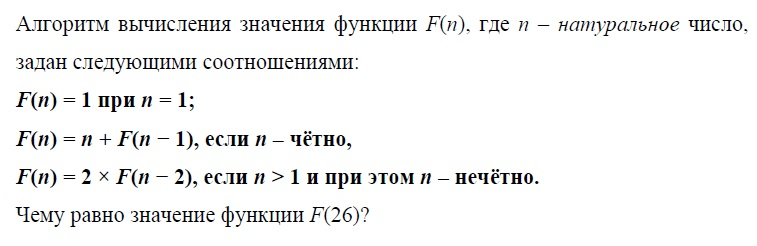

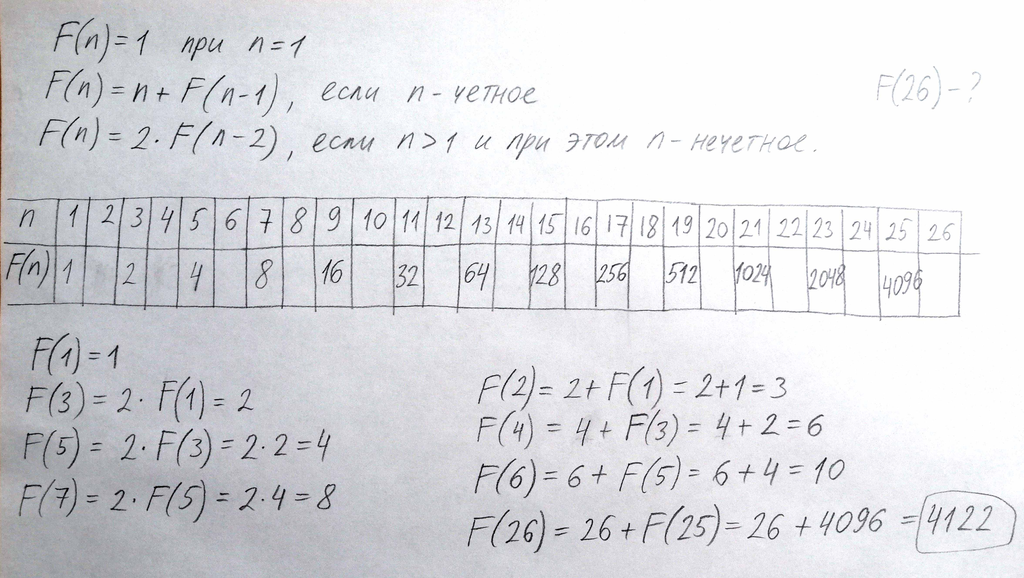

```python
def function(n):
    if n == 1:
        return 1
    if n % 2 == 0:
        return n + function(n-1)
    else:
        return 2 * function(n-2)

function(26)
# function(2)
# function(3)
```

```
4122
```

### ЗАДАНИЕ 16. Статград Тренировочная работа №2 от 10.12.2020.

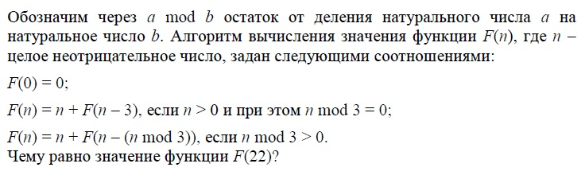

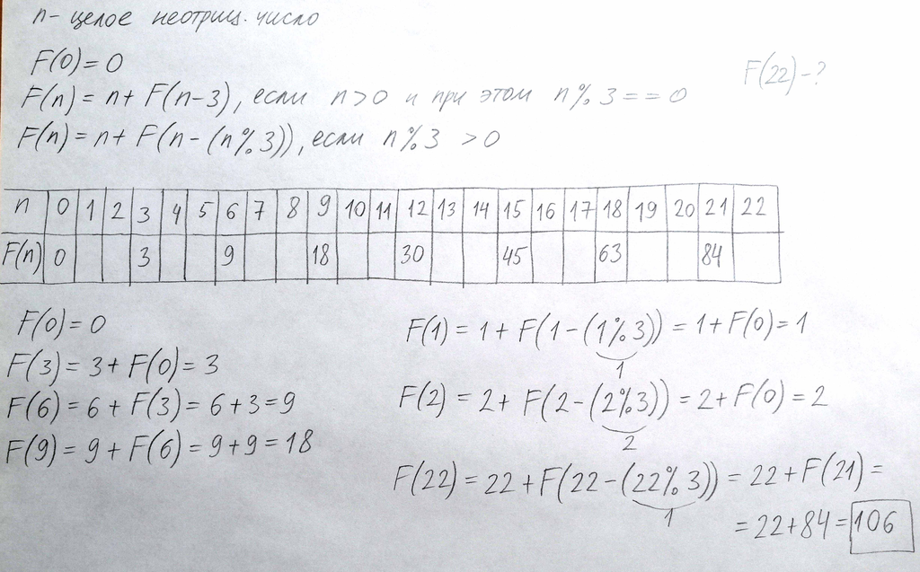

```python
def f(n):
    if n == 0:
        return 0
    if n % 3 == 0:
        return n + f(n - 3)
    else:
        return n + f(n - (n % 3))

f(22)
```

```
106
```

### ЗАДАНИЕ 17. Демонстрационный вариант ЕГЭ 2021.

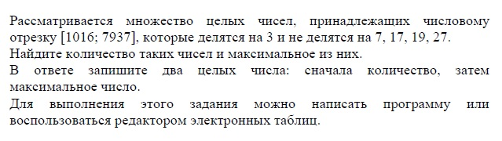

```python
# способ №1
count = 0
for number in range(1016, 7937+1):
    if number % 3 == 0 and number % 7 != 0 and number % 17 != 0 and number % 19 != 0 and number % 27 != 0:
        count += 1
        m = number
print(count, m)
```

```
1568 7935
```

```python
# способ №2
count = 0
possible_numbers = []
for number in range(1016, 7937+1):
    if number % 3 == 0 and number % 7 != 0 and number % 17 != 0 and number % 19 != 0 and number % 27 != 0:
        count += 1
        possible_numbers.append(number)
print(count, max(possible_numbers))
```

```
1568 7935
```

### ЗАДАНИЕ 17. Статград Тренировочная работа №2 от 10.12.2020.

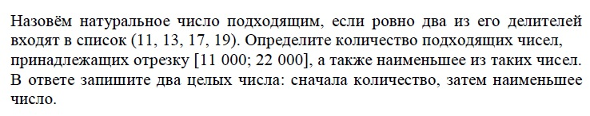

```python
# способ №1
numbers = []

for i in range(11000, 22000 + 1):
    if i % 11 == 0:
        if i % 13 == 0:
            if i % 17 != 0 and i % 19 != 0:
                numbers.append(i)
        elif i % 17 == 0 and i % 19 != 0:
            numbers.append(i)
        elif i % 19 == 0 and i % 17 != 0:
            numbers.append(i)
    elif i % 13 == 0:
        if i % 17 == 0 and i % 19 != 0:
            numbers.append(i)
        elif i % 19 == 0 and i % 17 != 0:
            numbers.append(i)
    elif i % 17 == 0 and i % 19 == 0:
        numbers.append(i)

print(len(numbers), min(numbers))
```

```
273 11011
```

```python
# способ №2
numbers = []

for i in range(11000, 22000 + 1):
    count = 0
    if i % 11 == 0:
        count += 1
    if i % 13 == 0:
        count += 1
    if i % 17 == 0:
        count += 1
    if i % 19 == 0:
        count += 1
    if count == 2:
        numbers.append(i)

print(len(numbers), min(numbers))
```

```
273 11011
```

## Структуры данных: список

Список — это структура данных, которая позволяет хранить последовательности чисел, строк или каких-либо ещё значений.

### Создание списков

```python
# создаем список, используя квадратные скобки или функцию list()
empty_list = []
empty_list = list()
```

```python
russian_alphabet = ['а','б','в','г','д','е','ё','ж','з','и','й','к','л',
                    'м','н','о','п','р','с','т','у','ф','х','ц','ч','ш',
                    'щ','ъ','ы','ь','э','ю','я']
print(russian_alphabet)
```

```
['а', 'б', 'в', 'г', 'д', 'е', 'ё', 'ж', 'з', 'и', 'й', 'к', 'л', 'м', 'н', 'о', 'п', 'р', 'с', 'т', 'у', 'ф', 'х', 'ц', 'ч', 'ш', 'щ', 'ъ', 'ы', 'ь', 'э', 'ю', 'я']
```

```python
# доступ к элементу
print(russian_alphabet[2])  # содержимое элемента с индексом 2
print(russian_alphabet[-2]) # содержимое второго с конца элемента
```

```
в
ю
```

```python
# удаление элемента
example_list = [10, 15, 5, 55, 'python']
print(example_list)
del example_list[-1]
print(example_list)
```

```
[10, 15, 5, 55, 'python']
[10, 15, 5, 55]
```

```python
len(russian_alphabet) # len() - функция для подсчёта элементов списка
```

```
33
```

```python
# добавляем элемент в конец списка
example_list = [1, True, 'a']
print(example_list)
example_list.append('PYTHON')
print(example_list)
```

```
[1, True, 'a']
[1, True, 'a', 'PYTHON']
```

### Сортировка

```python
# cортировка списка
# метод .sort() для списка меняет этот список
unsorted_list = [2, 1, 5, 4, 3]
print(unsorted_list)
unsorted_list.sort() # по умолчанию сортировка по возрастанию
print(unsorted_list)
unsorted_list.sort(reverse=True) # сортировка по убыванию
print(unsorted_list)
```

```
[2, 1, 5, 4, 3]
[1, 2, 3, 4, 5]
[5, 4, 3, 2, 1]
```

```python
# функция sorted() возвращает новый список с отсортированными данными
unsorted_list = [2, 1, 5, 4, 3]
print(unsorted_list)
print(sorted(unsorted_list)) # по умолчанию сортировка по возрастанию
print(sorted(unsorted_list, reverse=True)) # сортировка по убыванию
```

```
[2, 1, 5, 4, 3]
[1, 2, 3, 4, 5]
[5, 4, 3, 2, 1]
```

```python
# max()/min()
print(max(unsorted_list))
print(min(unsorted_list))
```

```
5
1
```

```python
# sum()
sum(unsorted_list)
```

```
15
```

### Задача 14

Отсортировать список по убыванию.

```python
new_list = [2, 1, 5, 4, 3]
# код
```

### Задача 15

Пользователем через пробел вводятся несколько чисел. Вывести минимальное и максимальное число.

```python
numbers = input('Введите через пробел несколько чисел: ')
splitted_numbers = numbers.split()
new_numbers = []
for item in splitted_numbers:
    new_numbers.append(int(item))
print(min(new_numbers), max(new_numbers))
```

```
Введите через пробел несколько чисел: 2 19 4
2 19
```

### Задача 16

Вывести на печать элементы списка.

```python
numbers = [1, 2, 3]

# способ №1
print(numbers[0], numbers[1], numbers[2])

# способ №2
for elem in numbers:
    print(elem, end=' ')
print()

# способ №3
print(*numbers)
```

```
1 2 3
1 2 3
1 2 3
```

### ЗАДАНИЕ 25. Демонстрационный вариант ЕГЭ 2021.

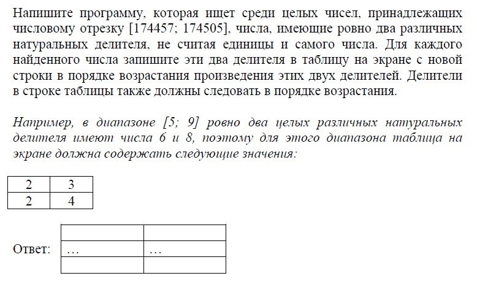

```python
# способ №1
for number in range(174457, 174505+1):
    count = 0
    divisors = []
    for div in range(2, number):
        if number % div == 0:
            count += 1
            divisors.append(div)
    if count == 2:
        for elem in divisors:
            print(elem, end=' ')
        print()
```

```
3 58153
7 24923
59 2957
13 13421
149 1171
5 34897
211 827
2 87251
```

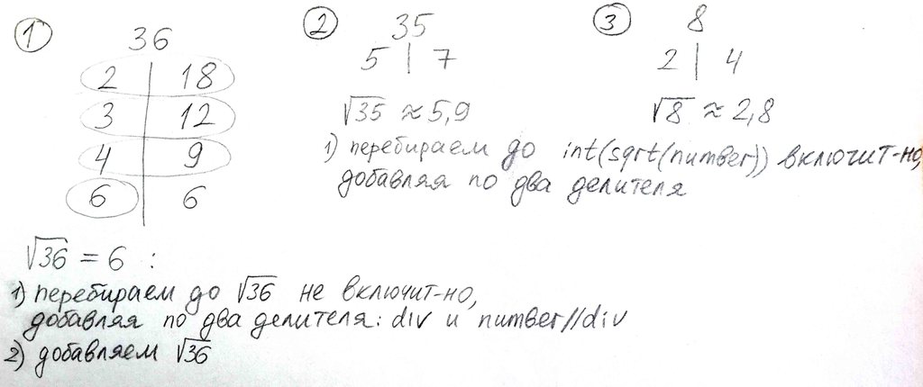

```python
# способ №2 (оптимальный способ: перебираем до корня из числа)
from math import sqrt

for number in range(174457, 174505+1):
    divisors = []
    for div in range(2, int(sqrt(number))):
        if number % div == 0:
            divisors.append(div)
            divisors.append(number//div)
        if len(divisors) > 2:
            break
    if number % int(sqrt(number)) == 0:
        divisors.append(int(sqrt(number)))
        if sqrt(number) != int(sqrt(number)):
            divisors.append(number//int(sqrt(number)))
    if len(divisors) == 2:
        print(*sorted(divisors))
# символом * распаковывают список и возвращают каждый его элемент.
```

```
3 58153
7 24923
59 2957
13 13421
149 1171
5 34897
211 827
2 87251
```

### ЗАДАНИЕ 25. Статград Тренировочная работа №2 от 10.12.2020.

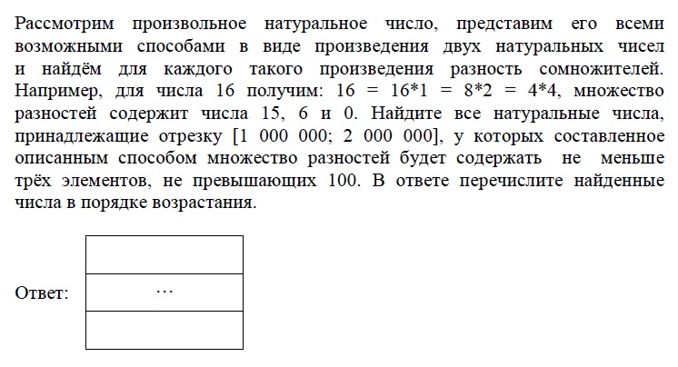

```python
# способ №1
for number in range(1_000_000, 2_000_000):
    count = 0
    div = 1
    while div * div <= number:
        if number % div == 0:
            if number//div - div <= 100:
                count += 1
            if count == 3:
                break
        div += 1
    if count == 3:
        print(number)
```

```
1113840
1179360
1208844
1499400
```

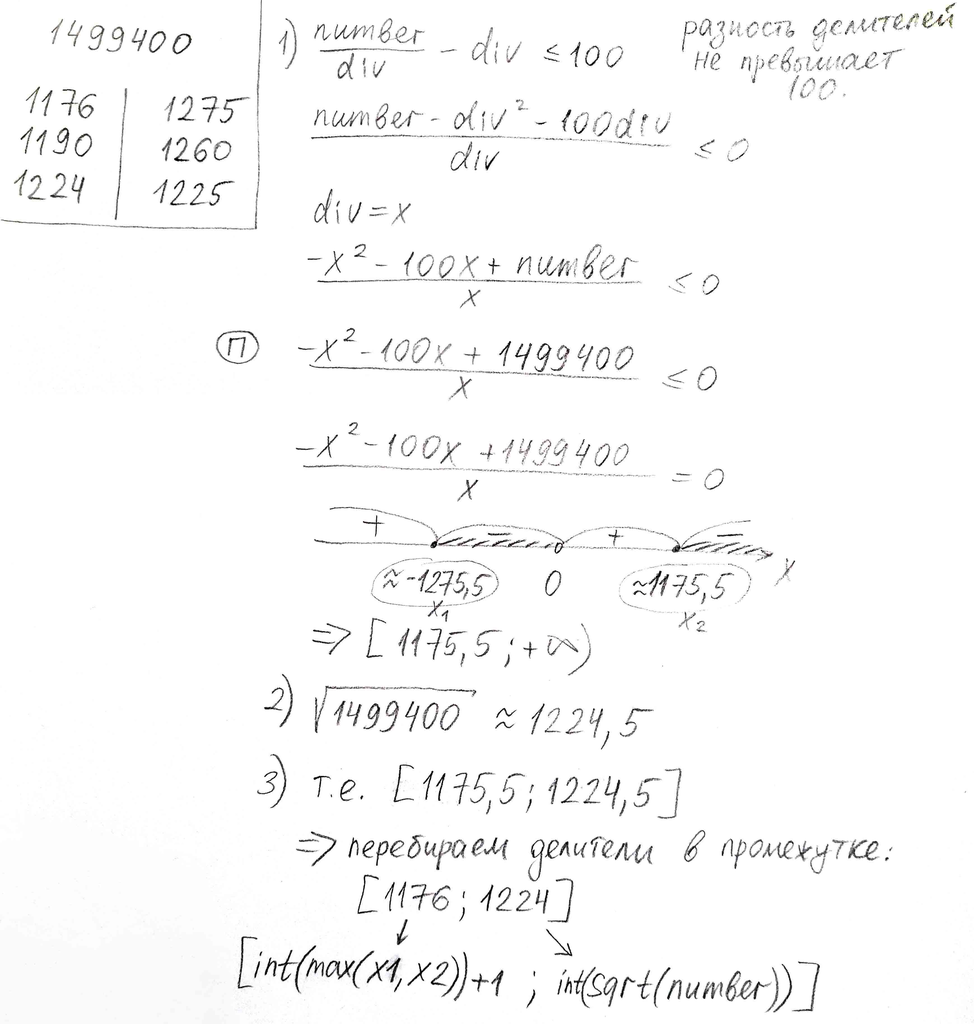

```python
# способ №2 (оптимальный способ: проверяем только те делители, у которых разность <= 100)
from math import sqrt

def div_range(c, a=-1, b=-100):
    """ number/div - div <=  100 """
    D = b**2 - 4*a*c
    x1 = (-b + sqrt(D))/(2*a)
    x2 = (-b - sqrt(D))/(2*a)
    return int(max(x1, x2)) + 1

for number in range(1_000_000, 2_000_000):
    count = 0
    for div in range(div_range(number), int(sqrt(number))+1):
        if number % div == 0:
            count += 1
            if count == 3:
                break
    if count == 3:
        print(number)
```

```
1113840
1179360
1208844
1499400
```

### Функция map()

> принимает два аргумента: функцию и аргумент составного типа данных, например, список, и применяет к каждому элементу списка переданную функцию.

Например, вы прочитали из файла список чисел, изначально все эти числа имеют строковый тип данных, чтобы работать с ними, нужно превратить их в целые числа.

```python
old_list = ['1', '2', '3', '4', '5', '6', '7']
new_list = []

for item in old_list:
    new_list.append(int(item))

print(old_list)
print(new_list)
```

```
['1', '2', '3', '4', '5', '6', '7']
[1, 2, 3, 4, 5, 6, 7]
```

```python
# применив функцию map()
old_list = ['1', '2', '3', '4', '5', '6', '7']
new_list = list(map(int, old_list))
print(old_list)
print(new_list)
```

```
['1', '2', '3', '4', '5', '6', '7']
[1, 2, 3, 4, 5, 6, 7]
```

```python
x = map(type, [3, 5.6, '1', True])
list(x)
```

```
[int, float, str, bool]
```

## АНАЛИЗ КОДА. ЗАДАНИЕ 6, 22.

**Пример 1.** Определите, при каком наименьшем введенном значении переменной x программа выведет сначала 2, а потом 13.

```
                                                x = int(input())
                                                a, b = 0, 0
                                                while x > 0:
                                                    a = a + 1
                                                    b = b + x % 10
                                                    x = x // 10
                                                print(a)
                                                print(b)
```

```python
for x in range(1, 100):
    a, b = 0, 0
    number = x
    while x > 0:
        a = a + 1
        b = b + x % 10
        x = x // 10
    if a == 2 and b == 13:
        print(number)
        break
```

```
49
```

**Пример 2.** Определите, при каком наименьшем введенном значении переменной s программа выведет число 60.

```
                                                s = int(input())
                                                s = (s + 1) // 7
                                                n = 36
                                                while s < 2050:
                                                    s = s * 2
                                                    n = n + 3
                                                print(n)
```

```python
for s in range(6, 100):
    number = s
    s = (s + 1) // 7
    n = 36
    while s < 2050:
        s = s * 2
        n = n + 3
    if n == 60:
        print(number)
        break
```

```
62
```

**Пример 3.** Определите, при каком наименьшем введенном значении переменной x программа выведет сначала 3, а потом 16.

```
                                                x = int(input())
                                                a = 0
                                                b = 0
                                                while x > 0:
                                                    a = a + 1
                                                    if x % 2 == 0:
                                                        b = b + x % 10
                                                    x = x // 10
                                                print(a)
                                                print(b)
```

```python
for x in range(1, 1000):
    a = 0
    b = 0
    number = x
    while x > 0:
        a = a + 1
        if x % 2 == 0:
            b = b + x % 10
        x = x // 10
    if a == 3 and b == 16:
        print(number)
        break
```

```
188
```

## Работа с файлами

```python
# читаем файл целиком
# 'r' - открытие файла на чтение
with open('text.txt', 'r') as file:
    print(file.read())
```

```
15 2 3 22
```

```python
# readlines()
```

```python
# %%time
```

```python
# import time
# start_time = time.time()


# end_time = time.time()
# end_time - start_time
```

```python
# Алгоритмы сортировок
```

```python
# Двумерные массивы
```

```python
# Алгоритм Евклида – это алгоритм нахождения наибольшего общего делителя (НОД) пары целых чисел.
```

```python
# range() -> start, stop, step
```